[figure not shown]

[figure not shown]

# Eksempel 3.1

### Indlæsning af data

12 målinger af klorofylproduktionen (**chloro**) i vinterhvede. Målingerne er inddelt i grupper mht. behandlingsfaktoren (betegnet **treat** i datasættet) med niveauer

- **kontrol**
- **glycine betaine**
- **glycine betaine+MnSO4**.

```r
data <- read.table("../data/chloro.txt", header = T)
data
```

```
   treat chloro
1      1     54
2      1     46
3      1     44
4      1     53
5      2     62
6      2     65
7      2     74
8      2     68
9      3     76
10     3     69
11     3     84
12     3     74
```

### Visualisering af data

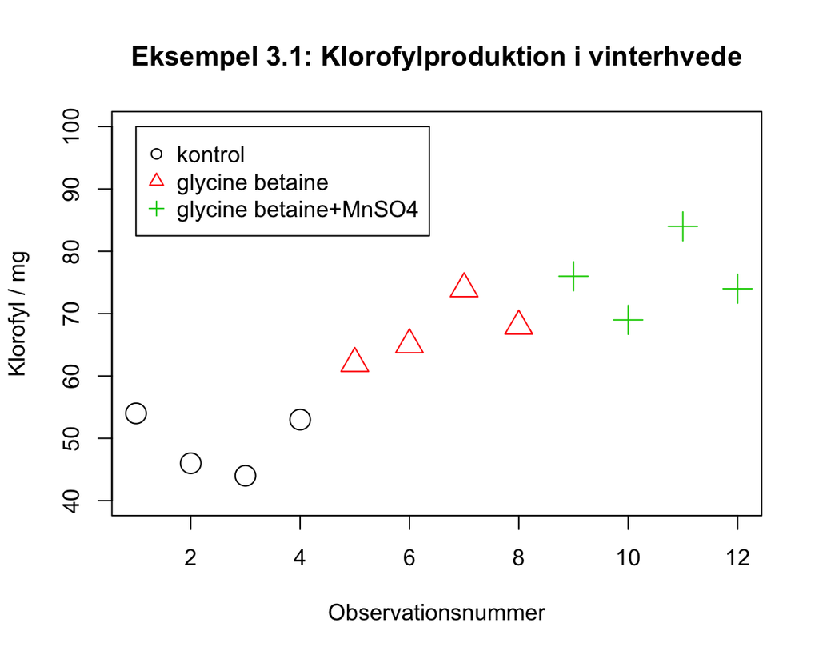

# Koagulation

### Indlæsning af data

```r
data <- read.table("../data/koagul.txt", header = T)
data
```

```
   foder tid
1      A  63
2      A  67
3      A  71
4      A  64
5      A  65
6      B  68
7      B  66
8      B  71
9      B  67
10     B  68
11     C  56
12     C  62
13     C  60
14     C  61
15     C  63
```

### Nyttige kommandoer

Kommandoer til undersøgelse af forsøgsdesign / datasæt

```r
names(data) ### navne på variable i datasættet
```

```
[1] "foder" "tid"
```

```r
head(data, 6) ### de første 6 linjer i datasættet
```

```
  foder tid
1     A  63
2     A  67
3     A  71
4     A  64
5     A  65
6     B  68
```

```r
### tabel over antal observationer for hvert niveau af faktoren foder
with(data, table(foder))
```

```
foder
A B C
5 5 5
```

```r
table(data$foder)
```

```
A B C
5 5 5
```

### Ensidet variansanalyse

Fit ensidet variansanalysemodel og test hypotese om, at fodertypen ikke har indflydelse på koagulationstiden.

```r
modelA <- lm(tid ~ foder, data = data)
modelB <- lm(tid ~ 1, data = data)
anova(modelB, modelA)
```

```
Analysis of Variance Table

Model 1: tid ~ 1
Model 2: tid ~ foder
  Res.Df   RSS Df Sum of Sq      F   Pr(>F)
1     14 238.4
2     12  83.2  2     155.2 11.192 0.001807 **
---
Signif. codes:  0 '***' 0.001 '**' 0.01 '*' 0.05 '.' 0.1 ' ' 1
```

Konklusion:

p-værdien p=0.001807 er meget lille, hvorfor vi FORKASTER hypotesen om, at fodertypen IKKE har betydning for koagulationstiden for blodet.

På godt dansk:

Vi kan ikke antage, at der er samme koagulationstider for rotterne i de tre grupper givet ved variablen (faktoren) ‘fodertype’.

### Standardparametrisering i R

Lad os kigge lidt mere på output fra en ensidet variansanalysemodel fittet med lm-funktionen i R.

```r
summary(modelA)
```

```
Call:
lm(formula = tid ~ foder, data = data)

Residuals:
   Min     1Q Median     3Q    Max
  -4.4   -1.5    0.0    1.3    5.0

Coefficients:
            Estimate Std. Error t value Pr(>|t|)
(Intercept)   66.000      1.178  56.048 6.86e-16 ***
foderB         2.000      1.665   1.201  0.25294
foderC        -5.600      1.665  -3.363  0.00565 **
---
Signif. codes:  0 '***' 0.001 '**' 0.01 '*' 0.05 '.' 0.1 ' ' 1

Residual standard error: 2.633 on 12 degrees of freedom
Multiple R-squared:  0.651, Adjusted R-squared:  0.5928
F-statistic: 11.19 on 2 and 12 DF,  p-value: 0.001807
```

Heraf ses, at:

- middelværdi for foder=A (=Intercept) estimeres til 66.0
- middelværdi for foder=B estimeres til 66.0+2.0=68.0
- middelværdi for foder=C estimeres til 66-5.6=60.4
- standard deviation estimeres til 2.633

### Alternativ (simpel) parametrisering

Genfit modellen med alternative parametriseringer

```r
modelA2 <- lm(tid ~ foder - 1, data = data)
summary(modelA2)
```

```
Call:
lm(formula = tid ~ foder - 1, data = data)

Residuals:
   Min     1Q Median     3Q    Max
  -4.4   -1.5    0.0    1.3    5.0

Coefficients:
       Estimate Std. Error t value Pr(>|t|)
foderA   66.000      1.178   56.05 6.86e-16 ***
foderB   68.000      1.178   57.75 4.80e-16 ***
foderC   60.400      1.178   51.29 1.98e-15 ***
---
Signif. codes:  0 '***' 0.001 '**' 0.01 '*' 0.05 '.' 0.1 ' ' 1

Residual standard error: 2.633 on 12 degrees of freedom
Multiple R-squared:  0.9987,    Adjusted R-squared:  0.9984
F-statistic:  3036 on 3 and 12 DF,  p-value: < 2.2e-16
```

Bemærk, at med parametriseringen i modelA2 kan direkte aflæses de 3 estimater svarende til fodertype A, B og C.

Konfidensintervaller kan fås med kommandoen

```r
confint(modelA2)
```

```
         2.5 %  97.5 %
foderA 63.4343 68.5657
foderB 65.4343 70.5657
foderC 57.8343 62.9657
```

Alternativt kan man beregne konfidensintervaller i ensidet variansanalysemodel ved at benytte formel (3.8) fra kompendiet.

# Lineær regression

### Indlæsning af data

Eksempel fra SD1-noter/bog:

9 sammenhørende målinger af stearinsyreindhold, acid, i fedt (målt i %) og fordøjeligheden, dig (målt i %).

```r
data<-read.table(file= "../data/linreg.txt", header=T)
data
```

```
  acid  dig
1 29.8 67.5
2 30.3 70.6
3 22.6 72.0
4 18.7 78.2
5 14.8 87.0
6  4.1 89.9
7  4.4 91.2
8  2.8 93.1
9  3.8 96.7
```

Er det rimelig at modellere fordøjeligheden ved en lineær funktion af stearinsyreindhold?

### Lineær regression

Når både responsvariabel (her: **dig**) og forklarende variabel (her: **acid**) er numeriske variable, så vil R’s standard-reaktion være at estimere parametrene (dvs. skæring og hældning) for den rette linje, der bedste beskriver målingerpunkterne, når de to variable plottes imod hinanden.

```r
modellin <- lm(data$dig~data$acid)
summary(modellin)
```

```
Call:
lm(formula = data$dig ~ data$acid)

Residuals:
    Min      1Q  Median      3Q     Max
-3.4308 -1.2249 -0.8724  2.3590  4.2860

Coefficients:
            Estimate Std. Error t value Pr(>|t|)
(Intercept) 96.53336    1.67518   57.63 1.24e-10 ***
data$acid   -0.93374    0.09262  -10.08 2.03e-05 ***
---
Signif. codes:  0 '***' 0.001 '**' 0.01 '*' 0.05 '.' 0.1 ' ' 1

Residual standard error: 2.97 on 7 degrees of freedom
Multiple R-squared:  0.9356,    Adjusted R-squared:  0.9264
F-statistic: 101.6 on 1 and 7 DF,  p-value: 2.028e-05
```